# Math 420 HW 1

## Problem 4

#### Consider an experimental situation where the investigator was interested in detecting a maximum difference in treatment means that is twice the standard deviation of the response measured on replicate experimental units assigned to the same level of the treatment factor, that is $\Delta = 2\sigma.$ If there are 4 levels of the treatment factor: (a)Modify the R code in Section 2.7 (of the DAE with R text) to calculate the power of various numbers of replicates $r$ per treatment level.

```r
library(daewr)
rmin<-2
rmax<-6
alpha<-rep(0.05,rmax-rmin+1)
sigma<-sqrt(2.1)
nlev<-4
nreps<-rmin:rmax
Delta<-2*sigma
power<-Fpower1(alpha,nlev,nreps,Delta,sigma)
power
```

```
##      alpha nlev nreps    Delta    sigma     power
## [1,]  0.05    4     2 2.898275 1.449138 0.1698028
## [2,]  0.05    4     3 2.898275 1.449138 0.3390584
## [3,]  0.05    4     4 2.898275 1.449138 0.5037050
## [4,]  0.05    4     5 2.898275 1.449138 0.6442332
## [5,]  0.05    4     6 2.898275 1.449138 0.7545861
```

(b)Calculate the number of replicates necessary to have 0.9 power of detecting a difference as large as $\Delta = 2\sigma$

```r
library(daewr)
target_power<-0.9
alpha<-0.05
sigma<-sqrt(2.1)
nlev<-4
Delta<-2*sigma
r<-2
current_power<-0
while(all(current_power<target_power)){
  current_power<-Fpower1(rep(alpha,r),nlev,r,Delta,sigma)
  #use "Fpower1()" to calculate the power for each value of r
  r<-r+1
}
print(r-1)#Because the loop increments r by 1 before stopping, the minimum r is r-1
```

[output not shown]

3. How would the result you got in (b) change if the number of levels of the treatment factor increased to 8, or decreased to 2?

1.the number of levels of the treatment factor increased to 8

```r
library(daewr)
target_power<-0.9
alpha<-0.05
sigma<-sqrt(2.1)
nlev_new1<-8
Delta<-2*sigma
r_new1<-2
current_power_new1<-0
while(all(current_power_new1<target_power)){
  current_power_new1<-Fpower1(rep(alpha,r_new1),nlev_new1,r_new1,Delta,sigma)
  r_new1<-r_new1+1
}
print(r_new1-1)
```

```
## [1] 2
```

2.the number of levels of the treatment factor decreased to 2

```r
library(daewr)
target_power<-0.9
alpha<-0.05
sigma<-sqrt(2.1)
nlev_new2<-2
Delta<-2*sigma
r_new2<-2
current_power_new2<-0
while(all(current_power_new2<target_power)){
  current_power_new2<-Fpower1(rep(alpha,r_new2),nlev_new2,r_new2,Delta,sigma)
  r_new2<-r_new2+1
}
print(r_new2-1)
```

```
## [1] 2
```

## Problem 5

#### A wooden catapult can be used to flip a foam ball. The catapult has three factors that can be adjusted: the start angle, the stop angle, and the pivot height. The distance the ball travels can be measured with a tape measure.

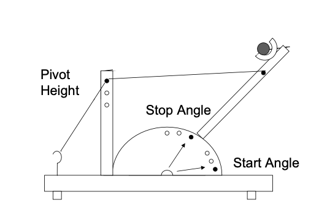

Figure 1

1. If experiments were to be conducted with the catapult by flipping the ball and measuring the distance, what would the experimental unit be?

   Experimental unit: A foam ball
2. Using the numbers 1, 2, and 3 to represent the levels of start angle and stop angle, and holding the pivot height constant at its high level, make a randomized list of experiments for a 3×3 factorial experiment with r = 2 replicates per cell.

```r
start_angle<-c(1,2,3)
stop_angle<-c(1,2,3)
experiment_design<-expand.grid(Start=start_angle,Stop=stop_angle)
experiment_design<-experiment_design[rep(seq_len(nrow(experiment_design)),each=2),]#r=2 replicates per cell
#make the experiments randomized
set.seed(123)
randomized_design<-experiment_design[sample(nrow(experiment_design)),]
randomized_design
```

|  | Start | Stop |
| --- | --- | --- |
| 8 | 2 | 3 |
| 7.1 | 1 | 3 |
| 2 | 2 | 1 |
| 5.1 | 2 | 2 |
| 1.1 | 1 | 1 |
| 3.1 | 3 | 1 |
| 6 | 3 | 2 |
| 3 | 3 | 1 |
| 2.1 | 2 | 1 |
| 7 | 1 | 3 |

[output cut: 8 more lines]

3. If the variance of the experimental error in the measured distance was $\sigma^2$ = 12 inches, calculate the number of replicates you would need to have a power of 0.90 for detecting a difference in 10 inches in cell means.

```r
library(daewr)
alpha<-0.05
sigma<-sqrt(12)
nlev<-3*3
Delta<-10
target_power<-0.9
r<-2
current_power<-0
while(all(current_power<target_power)){
  current_power<-Fpower1(rep(alpha,r),nlev,r,Delta,sigma)
  r<-r+1
}
print(r-1)
```

```
## [1] 2
```

4. Calculate the number of replicates you would need to have a power of 0.90 for detecting a difference of 24 inches in marginal means for either factor.

```r
library(daewr)
alpha<-0.05
sigma<-sqrt(12)
nlev<-3*3
Delta_new<-24
target_power<-0.9
r<-2
current_power<-0
while(all(current_power<target_power)){
  current_power<-Fpower1(rep(alpha,r),nlev,r,Delta_new,sigma)
  r<-r+1
}
print(r-1)
```

```
## [1] 2
```

5. If a catapult is available, conduct the list of experiments you wrote in part (b).
6. Calculate the ANOVA with your resulting data and test the main effects and interaction.
7. Explain or interpret any significant effects (use graphs if necessary to aid in your explanation).